# Ajuste de distribución de probabilidad a montos de pago de Siniestros de Credito a la Vivienda durante el 2020

Martha Paola Hernández Soto

Modelos Actuariales

Jorge Aguilar Velázquez

2022-11-18

## Introducción.

El presente trabajo tiene como objetivo desarrollar un ajuste de distribución (Log-Normal, Pareto, Weibull, Log-Gamma, Log-Logística) y también métodos no parámetricos (Kernel Uniforme, Triangular, Gamma), para un conjunto de datos que representan los montos pagados de créditos de vivienda durante el año 2020, la base de datos fue obtenida de los datos abiertos de la Comisión Nacional de Seguros y Fianzas y contiene un total de 324 observaciones.

## Marco Teórico.

### Distribuciones de probabilidad

La distribución de probabilidad es la función matemática que da las probabilidades de ocurrencia de diferentes resultados posibles para un experimento.Es una descripción matemática de un fenómeno aleatorio en términos de su espacio muestral y las probabilidades de eventos (subconjuntos del espacio muestral)

Para las distribuciones de las que haremos uso, a continuación se define su función de distribución de probabilidad.

#### Distribución Log-Normal.

$f (x) = \displaystyle {\frac {1}{x\sigma {\sqrt {2\pi }}}}\exp \left(-{\frac {(\ln x-\mu )^{2}}{2\sigma ^{2}}}\right){\text{, donde }}x>0$

#### Distribución Pareto.

$f (x) = \displaystyle {\frac {\alpha \,x_{\mathrm {m} }^{\alpha }}{x^{\alpha +1}}}{\text{, donde }}x>x_{m}\!$

#### Distribución Weibull.

$f (x) = \displaystyle \lambda \alpha (\lambda x)^{\alpha -1}e^{-(\lambda x)^{\alpha }}{\text{, donde }}x>0$

#### Distribución Log-Gamma.

$f (x) = \frac {e ^ {\beta x} e ^ {\frac {-e ^ x} {\alpha}}} {\alpha ^ \beta \Gamma (\beta)} \ \, donde - \infty \gt x \lt \infty$

#### Distribución Log-Logística.

$f (x) = \displaystyle {\frac {e^{-(x-\mu )/s}}{s\left(1+e^{-(x-\mu )/s}\right)^{2}}}{\text{, donde }}x>0\!$

### Kernel

Los métodos de estimación de densidad kernel, se utilizan para estimar densidades de datos que no tienen comportamientos estadisticos paramétricos.

Las funciones obtenidas de estos métodos cumplen las siguientes caracteristicas:

- Continuidad
- Simetría
- Positivas

Estas funciones permiten convertir lo que sería un problema de clasificación no lineal en el espacio dimensional original, a un sencillo problema de clasificación lineal en un espacio dimensional mayor.

#### Kernel Uniforme.

$k_{yj} (x) = \displaystyle {\frac {1}{2b}} ;\ \ y-b<x<y+b\!$

$k_{yj} (x) = \displaystyle 0 ;\ \ o.t.w.\!$

#### Kernel Triangular.

$k_{yj} (x) = \displaystyle {\frac {x-y+b}{b^2}} ;\ \ y-b<x<y\!$

$k_{yj} (x) = \displaystyle {\frac {y+b-x}{b^2}} ;\ \ y<x<y+b\!$

$k_{yj} (x) = \displaystyle 0 ;\ \ o.t.w.\!$

#### Kernel Gamma.

$k_{yj} (x) = \displaystyle {\frac {(\frac {2x}{y})^2e^{-(\frac{ax}{y})}}{2b}} ;\ \ 0<x\!$

#### Prueba K-S.

La prueba de Kolmogorov-Smirnov (Chakravart, Laha y Roy, 1967) se utiliza para decidir si una muestra proviene de una población con una distribución específica.

La prueba de Kolmogorov-Smirnov se define por:

- H0: Los datos siguen una distribución específica
- Ha: Los datos no siguen la distribución especificada

#### Prueba A-D.

La prueba de Anderson-Darling (Stephens, 1974) se usa para probar si una muestra de datos proviene de una población con una distribución específica. Es una modificación de la prueba de Kolmogorov-Smirnov (K-S) y da más peso a las colas que la prueba de K-S.

La prueba de Anderson-Darling se define como:

- H0: Los datos siguen una distribución específica.
- Ha: Los datos no siguen la distribución especificada

#### Prueba Chi-Cuadrada.

La prueba de chi-cuadrado (Snedecor y Cochran, 1989) se usa para probar si una muestra de datos proviene de una población con una distribución específica.

Una característica atractiva de la prueba de bondad de ajuste chi-cuadrado es que se puede aplicar a cualquier distribución univariada para la que se pueda calcular la función de distribución acumulativa. La prueba de bondad de ajuste chi-cuadrado se aplica a datos agrupados (es decir, datos colocados en clases).

La prueba de chi-cuadrado se define para la hipótesis:

- H0: Los datos siguen una distribución específica.
- Ha: Los datos no siguen la distribución especificada.

## Metodología.

Lo que se realizará es mediante una serie de librerías que ofrece R buscaremos estimar los mejores párametros para las distribuciones anteriormente mencionadas y para los métodos no parámetricos, para luego comparar los modelos resultantes por medio de pruebas de bondad de ajuste como la K-S, A-D, y Chi Cuadrada.

## Desarrollo.

Empezamos importando todas las librerias de las que haremos uso, para graficar, para ajustar a las distribuciones, para los distintos kernel que utilizaremos, y algunas librerías complementarías.

```r
library(ggplot2)
library(actuar)
library(survival)
library(MASS)
library(fitdistrplus)
library(moments)
library(nortest)
library(sandwich)
library(momentfit)
library(grid)
library(vcd)
library(fdth)
library(openxlsx)
library(kdensity)
```

Despues comenzaremos a limpiar los datos, para este trabajo decidí hacer uso de sólo una muestra de 98 datos, omitiendo los valores que contienen 0, para no tener posibles problemas con las distribuciones que no estén definidas en 0.

```r
db = read.csv("./db.csv")

db_clean = data.frame("Monto Pagado"=db$MONTO.PAGADO/10000)
db_clean = db_clean[c(1:100),]

print(paste("El número total de datos NA es: ",sum(is.na(db_clean))))
```

```
## [1] "El número total de datos NA es:  0"
```

```r
print(paste("El número total de datos iguales a 0 es: ",sum(db_clean==0)))
```

```
## [1] "El número total de datos iguales a 0 es:  2"
```

```r
db_clean = data.frame("Monto Pagado"=db_clean)
db_clean = db_clean[db_clean>0,]

data = data.frame("Monto Pagado"=db_clean)
```

A continuación se presenta un pequeño resumen de los datos que estaremos considerando en esta muestra, junto con una pequeña grafica de densidad de la muestra.

```
##     Min.  1st Qu.   Median     Mean  3rd Qu.     Max.
##    1.501   23.851   61.305  358.831  277.151 3180.337
```

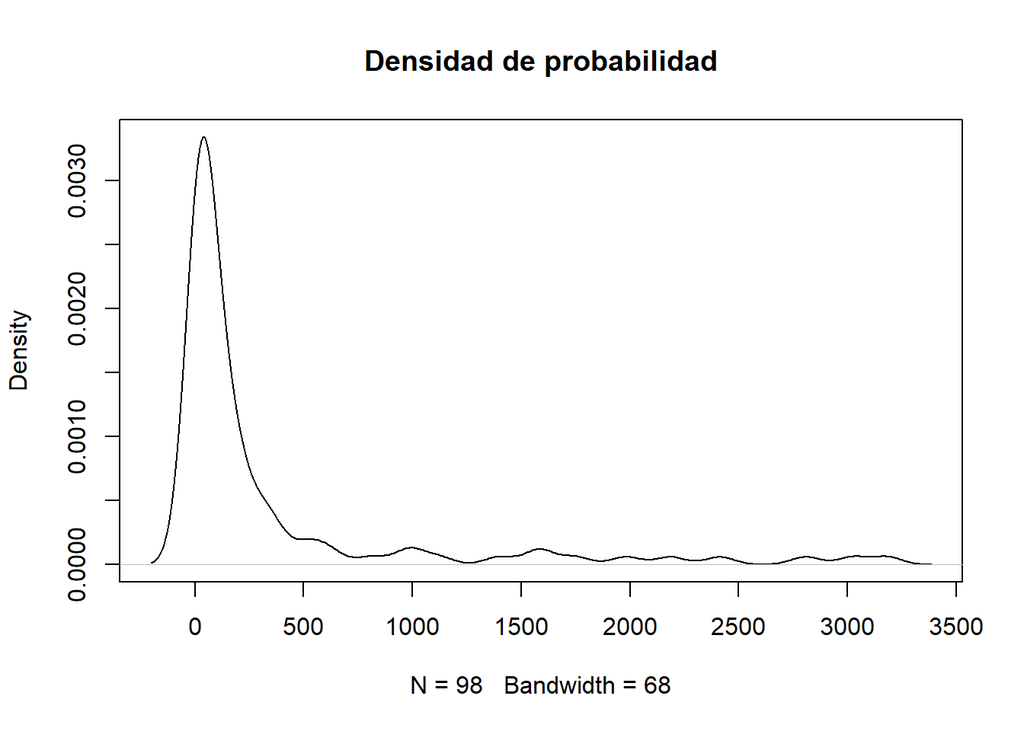

#### Log-Normal

Empezaremos ajustando los datos para la distribución Log-Normal.

```
## Fitting of the distribution ' lnorm ' by maximum likelihood
## Parameters :
##         estimate Std. Error
## meanlog 4.416283  0.1800468
## sdlog   1.782373  0.1273121
## Loglikelihood:  -628.4904   AIC:  1260.981   BIC:  1266.151
## Correlation matrix:
##         meanlog sdlog
## meanlog       1     0
## sdlog         0     1
```

```
##            2.5 %   97.5 %
## meanlog 4.063398 4.769169
## sdlog   1.532845 2.031900
```

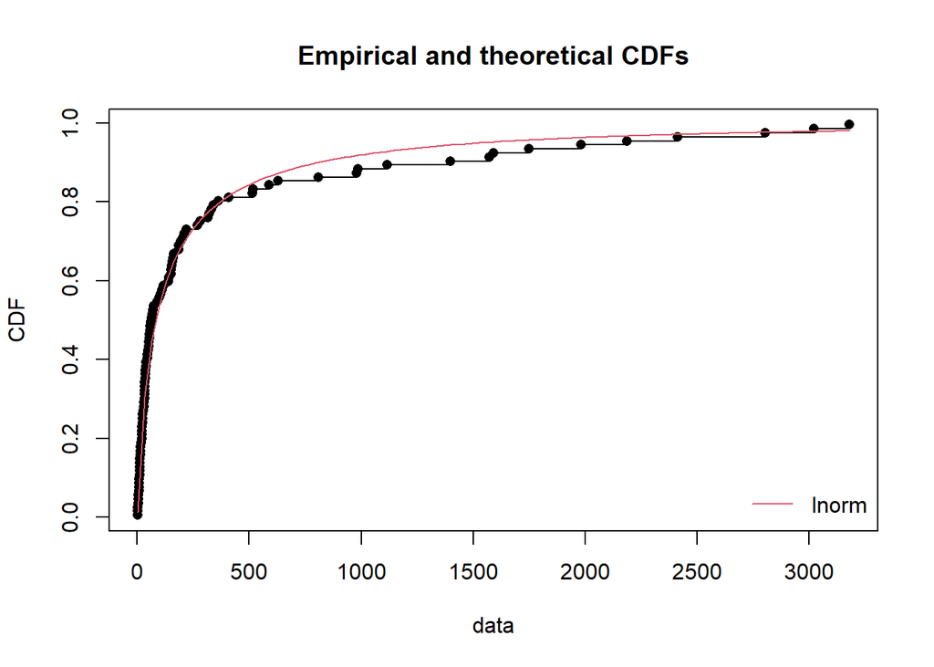

#### Pareto

Ahora ajustando los datos para la distribución Pareto.

```
## Fitting of the distribution ' pareto ' by maximum likelihood
## Parameters :
##         estimate Std. Error
## shape  0.8604172  0.1647583
## scale 61.6166642 21.6741639
## Loglikelihood:  -630.4825   AIC:  1264.965   BIC:  1270.135
## Correlation matrix:
##           shape     scale
## shape 1.0000000 0.8495356
## scale 0.8495356 1.0000000
```

```
##            2.5 %     97.5 %
## shape  0.5374969   1.183337
## scale 19.1360835 104.097245
```

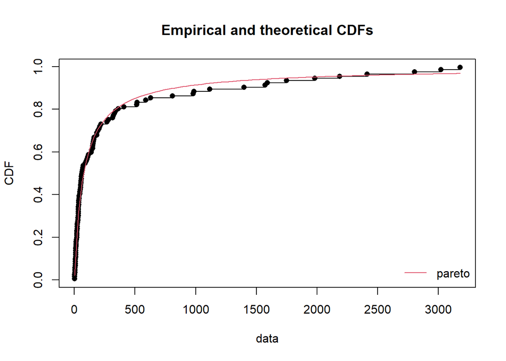

#### Weibull

Y ajustando los datos para la distribución Weibull.

```
## Fitting of the distribution ' weibull ' by maximum likelihood
## Parameters :
##          estimate  Std. Error
## shape   0.5707826  0.04258281
## scale 205.0182920 38.52282707
## Loglikelihood:  -636.4656   AIC:  1276.931   BIC:  1282.101
## Correlation matrix:
##           shape     scale
## shape 1.0000000 0.3357377
## scale 0.3357377 1.0000000
```

```
##             2.5 %      97.5 %
## shape   0.4873218   0.6542434
## scale 129.5149384 280.5216456
```

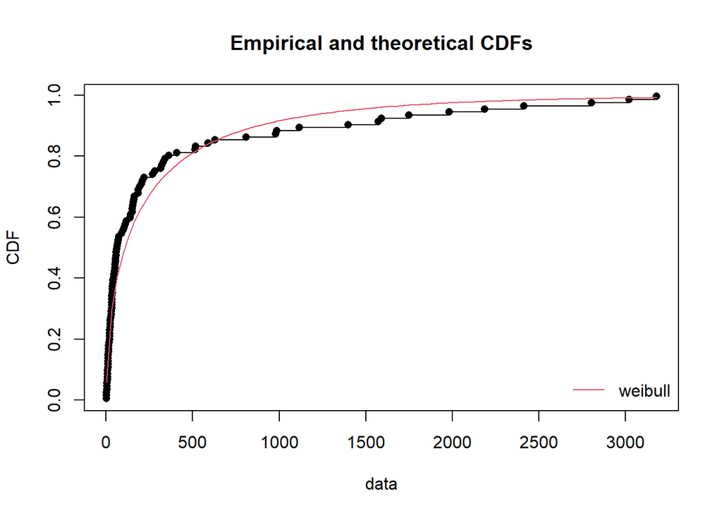

#### Log-Gamma

Continuamos ajustando los datos para la distribución Log-Gamma.

```
## Fitting of the distribution ' lgamma ' by maximum likelihood
## Parameters :
##          estimate Std. Error
## shapelog 4.992388  0.6906837
## ratelog  1.130364  0.1645209
## Loglikelihood:  -631.738   AIC:  1267.476   BIC:  1272.646
## Correlation matrix:
##           shapelog   ratelog
## shapelog 1.0000000 0.9505341
## ratelog  0.9505341 1.0000000
```

```
##              2.5 %   97.5 %
## shapelog 3.6386732 6.346103
## ratelog  0.8079093 1.452819
```

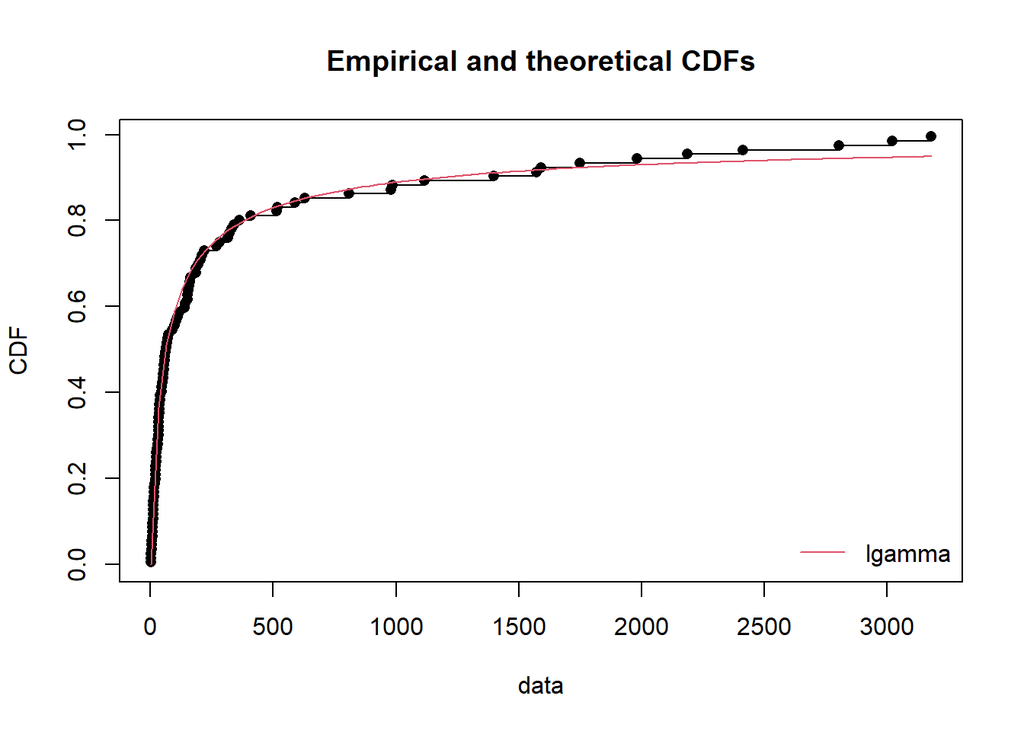

#### Log-Logistica

```
## Fitting of the distribution ' llogis ' by maximum likelihood
## Parameters :
##         estimate  Std. Error
## shape  0.9624366  0.08020927
## scale 78.2497305 14.43981583
## Loglikelihood:  -630.6764   AIC:  1265.353   BIC:  1270.523
## Correlation matrix:
##             shape       scale
## shape  1.00000000 -0.03438242
## scale -0.03438242  1.00000000
```

```
##            2.5 %     97.5 %
## shape  0.8052293   1.119644
## scale 49.9482115 106.551249
```

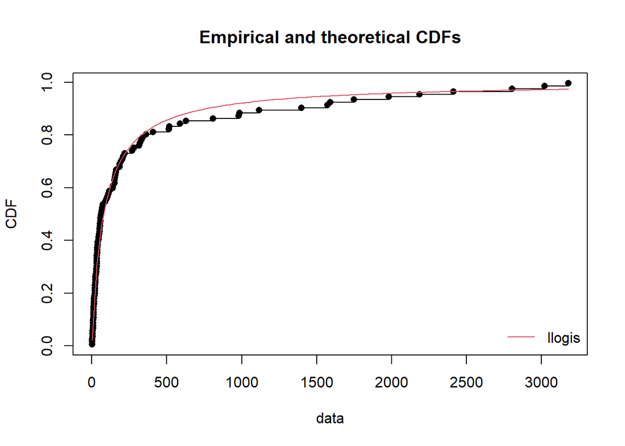

A partir del método de comparación gráfico podemos concluir que aparentemente la distribución que mejor se acomoda a los datos podría ser la distribución Log-Gamma, pero esto no es el mejor método para concluir este tipo de cosas, por lo que vamos a hacer las pruebas pertinentes para poder concluir de una mejor forma lo que necesitamos.

A continuación se desglosa una serie detallada de valores obtenidos a partir de la pruebas mencionadas en el marco teorico que nos servirán para ver cual es la mejor distribución para nuestra muestra.

```
## Goodness-of-fit statistics
##                              Log-Normal     Pareto   Weibull  Log-Gamma
## Kolmogorov-Smirnov statistic 0.07298693 0.05775305 0.1158722 0.07091651
## Cramer-von Mises statistic   0.07533801 0.05795845 0.3175955 0.07433104
## Anderson-Darling statistic   0.48596812 0.43326275 1.9930546 0.58363170
##                              Log-Logistica
## Kolmogorov-Smirnov statistic    0.06419901
## Cramer-von Mises statistic      0.07341922
## Anderson-Darling statistic      0.53726117
##
## Goodness-of-fit criteria
##                                Log-Normal   Pareto  Weibull Log-Gamma
## Akaike's Information Criterion   1260.981 1264.965 1276.931  1267.476
## Bayesian Information Criterion   1266.151 1270.135 1282.101  1272.646
##                                Log-Logistica
## Akaike's Information Criterion      1265.353
## Bayesian Information Criterion      1270.523
```

```
## $chisqpvalue
##    Log-Normal        Pareto       Weibull     Log-Gamma Log-Logistica
##    0.58537751    0.79821345    0.01492131    0.78562508    0.67066530
```

```
## $adtest
##     Log-Normal         Pareto        Weibull      Log-Gamma  Log-Logistica
## "not computed" "not computed"     "rejected" "not computed" "not computed"
```

```
## $kstest
##     Log-Normal         Pareto        Weibull      Log-Gamma  Log-Logistica
## "not rejected" "not rejected" "not rejected" "not rejected" "not rejected"
```

#### Ajuste no parámetrico (Kernel)

Ahora vamos a realizar la creación de los kernel uniforme, triangular y gamma para mediante una grafica poder ver cual es la que se ajusta mejor al modelo.

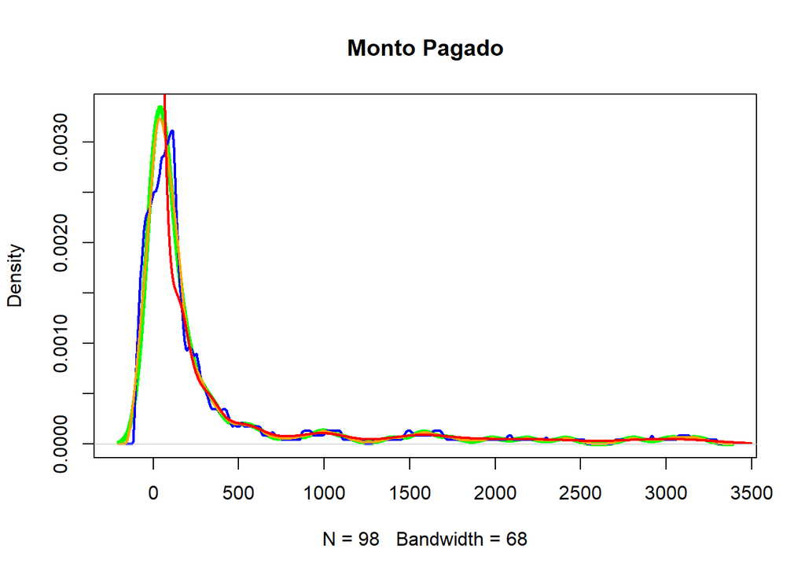

```r
plot(density(data$Monto.Pagado), col = "green", lwd=4, main = "Monto Pagado")
lines(kunif, col = "blue", lwd=2)
lines(ktriang, col = "orange", lwd=2)
lines(kgamma, col = "red", lwd=2)
```

## Conclusiones.

Pero el objetivo era encontrar la mejor distribución por lo que el trabajo aquí no termina, tomando en cuenta el criterio de Akaike donde nos menciona que entre menor sea el valor del AIC el modelo tiende a ser mejor, y de entre todos los modelos elegidos el que tiene el menor AIC es el de la distribución Log-Normal, por lo que para este trabajo y esta muestra de datos el resultado será que **la distribución Log-Normal es donde mejor se ajustan nuestros datos**.

```
## Goodness-of-fit statistics
##                              Log-Normal
## Kolmogorov-Smirnov statistic 0.07298693
## Cramer-von Mises statistic   0.07533801
## Anderson-Darling statistic   0.48596812
##
## Goodness-of-fit criteria
##                                Log-Normal
## Akaike's Information Criterion   1260.981
## Bayesian Information Criterion   1266.151
```

```
## $chisqpvalue
## [1] 0.5853775
```

```
## $adtest
##     Log-Normal
## "not computed"
```

```
## $kstest
##     Log-Normal
## "not rejected"
```

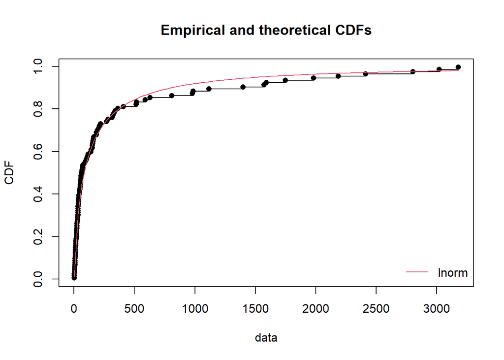

Y para el lado del método no párametrico, podemos concluir que el **Kernel triangular (naranja) cuenta con el mejor ajuste con la muestra (verde)** de los 3 utilizados.

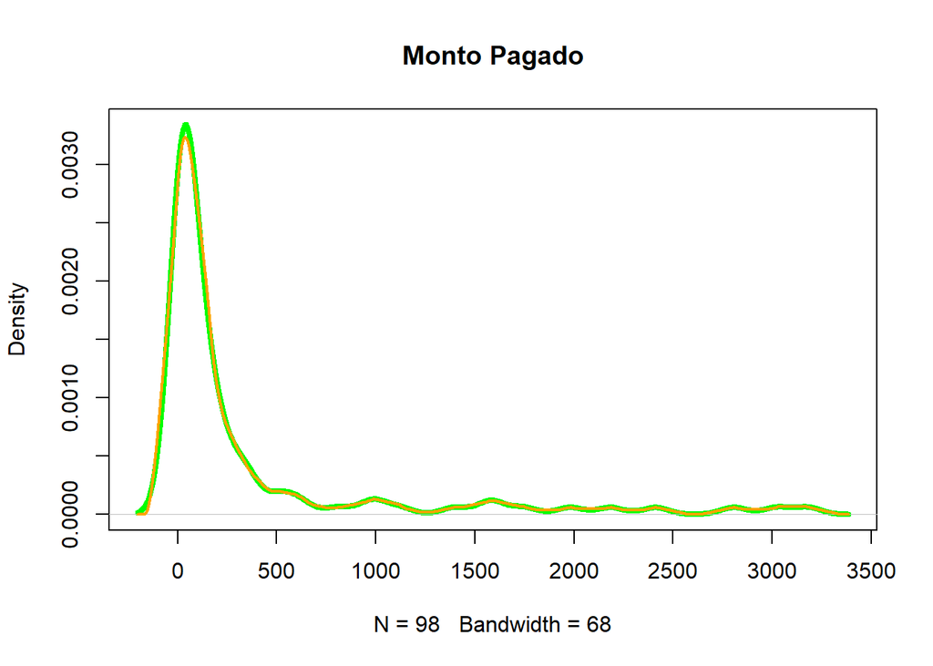

## Bibliografía.

- Broverman, Samuel. (2009). ACTEX STUDY MANUAL SOA EXAM C CAS EXAM 4. Estados Unidos: Actex publications
- Klugman, S. (2012). Loss Models. Estados Unidos: John Wiley & Sons, Inc
- TRANSPARENCIA DATOS ABIERTOS. (s. f.). https://www.cnsf.gob.mx/Transparencia/Paginas/DatosAbiertos.aspx
- fitdist function - RDocumentation. (s. f.). https://www.rdocumentation.org/packages/fitdistrplus/versions/1.1-8/topics/fitdist
- 1.3.5.14. Anderson-Darling Test. (s. f.). https://www.itl.nist.gov/div898/handbook/eda/section3/eda35e.htm
- 1.3.5.15. Chi-Square Goodness-of-Fit Test. (s. f.). https://www.itl.nist.gov/div898/handbook/eda/section3/eda35f.htm
- 1.3.5.16. Kolmogorov-Smirnov Goodness-of-Fit Test. (s. f.). https://www.itl.nist.gov/div898/handbook/eda/section3/eda35g.htm